# 2.1: Melting Ice Sheets

### Unit 2: Climate

#### Lesson 1: Melting Ice Sheets

#### Skills: read data, line plot, bar plot, saving plots, confidence intervals, indexing, arithmetic

**Don’t forget to fork the Unit 2 GitHub repository**

https://github.com/MSCI-758/unit_2_climate

Fork the repository to your own GitHub profile. From there, clone the forked repository and create a new RStudio project with version control called unit_2_climate on your local computer associated with this GitHub repo. Now you have access to all of the scripts, data and documentation files in the unit_2 class repo. I would recommend creating new `.R` files in your local RProject directory (i.e. the local version of your unit_2 repository) to type in the commands that we go over in class as you follow along. This gives you practice typing out code, and gives you the comfort to try new things without being afraid that you’ll “mess up” your copy of the tutorial. You can always refer back to the lesson tutorial that I wrote, which is sitting right in your local directory. As you follow along in your own script (or even the `.Rmd` tutorial files) you can insert your code for the in-class exercises right in the middle of the scripts. When you make changes to the repository by adding new scripts or editing the existing scripts, don’t forget to Commit and Push out your changes to your GitHub repo. Remember, those changes won’t show up in the class repository, they’ll only show up in **your** forked branch of the repository in your own GitHub profile.

#### Explore NASA melting ice sheet data

- Data description: http://climate.nasa.gov/vital-signs/land-ice/

The Antarctic and Greenland ice sheet mass loss data is collected by NASA’s GRACE satellites. This is a pair of satellites that orbit the Earth together at a distance of about 220 km apart to sense gravity anomalies. When the leading satellite orbits over a part of Earth with slightly stronger gravity, it is pulled ahead a bit faster. Then when it passes the high-gravity area, the satellite slows down again. The distance between the two satellites is consantly measured with a microwave ranging system, and this distance, combined with precise GPS measurements for each satellite in the pair, can be used to generate a map of Earth’s gravity field. Ice loss is correlated with a decline in the gravity anomaly over the ice sheet as the ice mass melts and redistributes across the ocean basin.

[figure not shown]

Check out this “Crazy Engineering: Microwaves and Lasers” video to learn more:

https://www.youtube.com/watch?v=hsdjssgbZoU&t=201s

#### Agenda:

- Construct the necessary R code to import this data set as a `data.frame` object.
- Examine the data set: what are the columns and units? Where do the numbers come from?
- What is the uncertainty in measurement? Resolution of the data? Interpretation of missing values?
- Plot the data and describe the trends you observe.

Go to the website and register yourself as a NASA Earthdata user. From there you can click on the data and download it. In your web browser, go to `File -> Save page as -> and save it as a text file` in your Rproj folder in a directory called `/data`.

#### Read in and explore data

Use `read.table()` to read in the `.txt` data. There are 3 columns, the decimal date, the mass loss (in Gigatonnes) and one sigma (i.e. one standard deviation in Gigatonnes). We use the default separator `sep=""` which distinguishes column data by looking for white space. We skip the first 31 lines of the `.txt` file because that’s all header (metadata). We manually code the column names after reading the header.

```r
ant_ice_loss = read.table("data/antarctica_mass_200204_202111.txt", skip=31, sep="", header = FALSE, col.names = c("decimal_date", "mass_Gt", "sigma_Gt")) # Antarctica ice mass loss
grn_ice_loss = read.table("data/greenland_mass_200204_202111.txt", skip=31, sep="", header = FALSE, col.names = c("decimal_date", "mass_Gt", "sigma_Gt")) # Greenland ice mass loss
```

Explore the data. See how it appears in the Environment pane (upper right corner of RStudio)? You can click on it here, or use the `View()` function to open it up in a spreadsheet inside RStudio. Be careful you don’t make changes to the spreadsheet in the View tab because it will change the data.

```r
# View(grn_ice_loss)
head(ant_ice_loss)
##   decimal_date mass_Gt sigma_Gt
## 1      2002.29    0.00   178.90
## 2      2002.35   23.21   102.47
## 3      2002.62  -53.37    83.09
## 4      2002.71   46.69    97.19
## 5      2002.79   69.68    61.82
## 6      2002.87  -60.96    58.68
head(grn_ice_loss)
##   decimal_date mass_Gt sigma_Gt
## 1      2002.29    0.00   134.28
## 2      2002.35   69.35    70.59
## 3      2002.62 -217.76    53.36
## 4      2002.71 -239.61    64.95
## 5      2002.79 -206.54    39.05
## 6      2002.87 -207.96    35.79
dim(ant_ice_loss)
## [1] 203   3
summary(ant_ice_loss)
##   decimal_date     mass_Gt            sigma_Gt
##  Min.   :2002   Min.   :-3032.26   Min.   : 26.73
##  1st Qu.:2007   1st Qu.:-1827.83   1st Qu.: 33.45
##  Median :2011   Median : -892.73   Median : 37.12
##  Mean   :2012   Mean   :-1080.37   Mean   : 38.97
##  3rd Qu.:2016   3rd Qu.: -303.07   3rd Qu.: 40.05
##  Max.   :2022   Max.   :   69.68   Max.   :178.90
```

Plot the data using a formula `y ~ x`

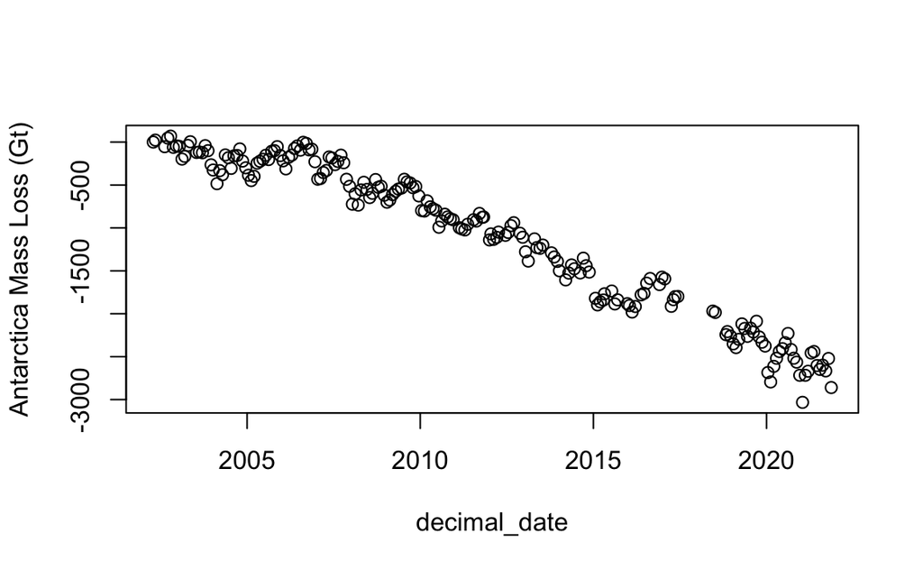

```r
# Plot Antarctic ice mass loss
plot(mass_Gt ~ decimal_date, data=ant_ice_loss, ylab="Antarctica Mass Loss (Gt)")
```

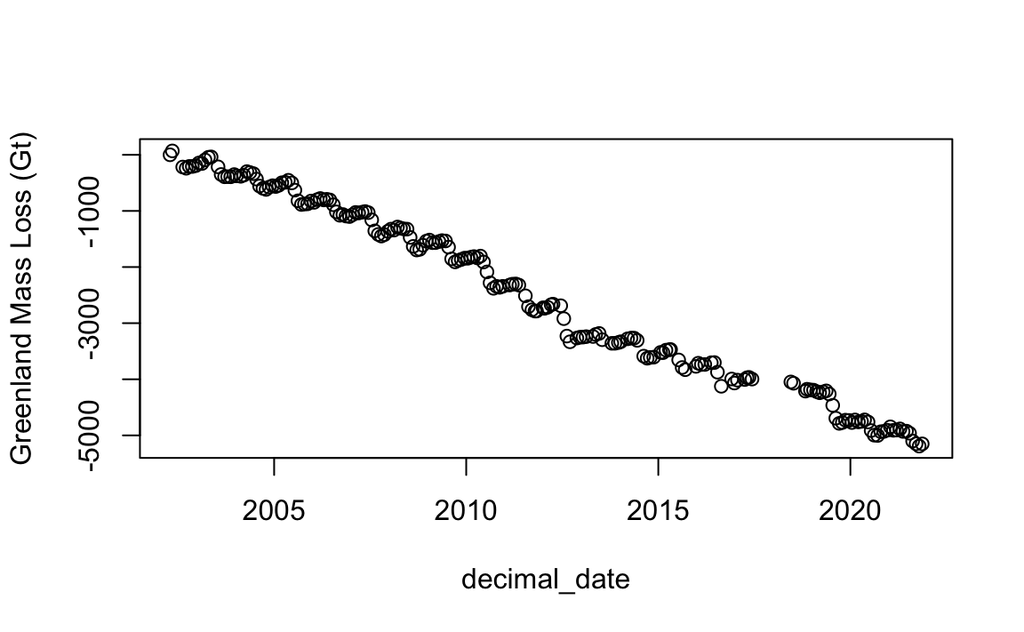

```r
# Plot Greenland ice mass loss
plot(mass_Gt ~ decimal_date, data=grn_ice_loss, ylab="Greenland Mass Loss (Gt)")
```

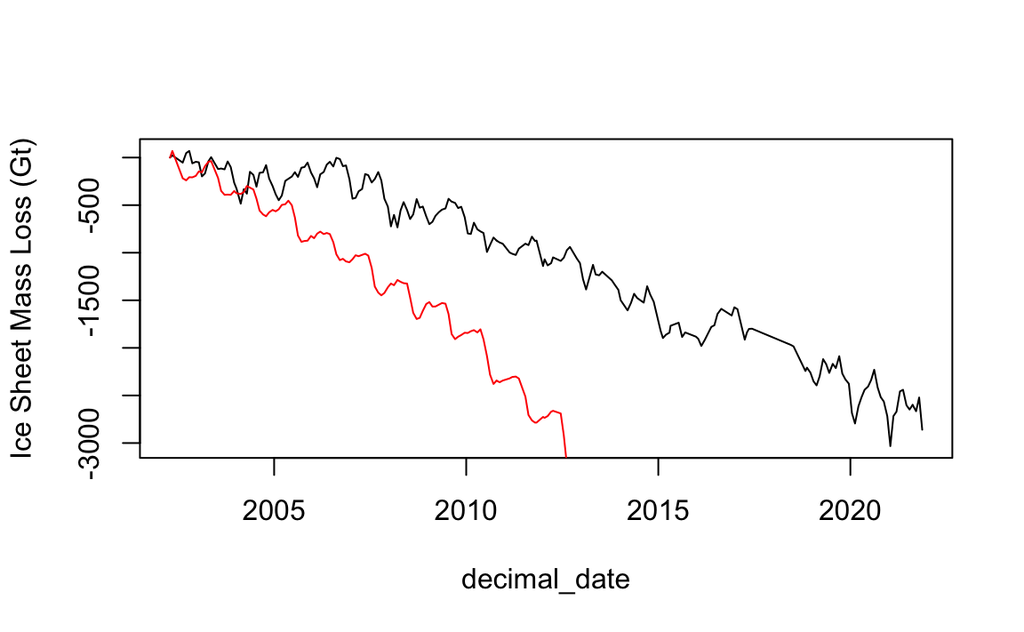

```r
# Plot both together as lines
plot(mass_Gt ~ decimal_date, data=ant_ice_loss, ylab="Ice Sheet Mass Loss (Gt)", type='l')
lines(mass_Gt ~ decimal_date, data=grn_ice_loss, col='red')
```

The plot window is sized to capture the range of the data originally called, which in this case was the Antarctica ice loss. When we added the Greenland mass loss data to the plot, it extended outside the bounds of the plot window. Let’s manually set the limits on the y-axis so we can see the whole Greenland time series.

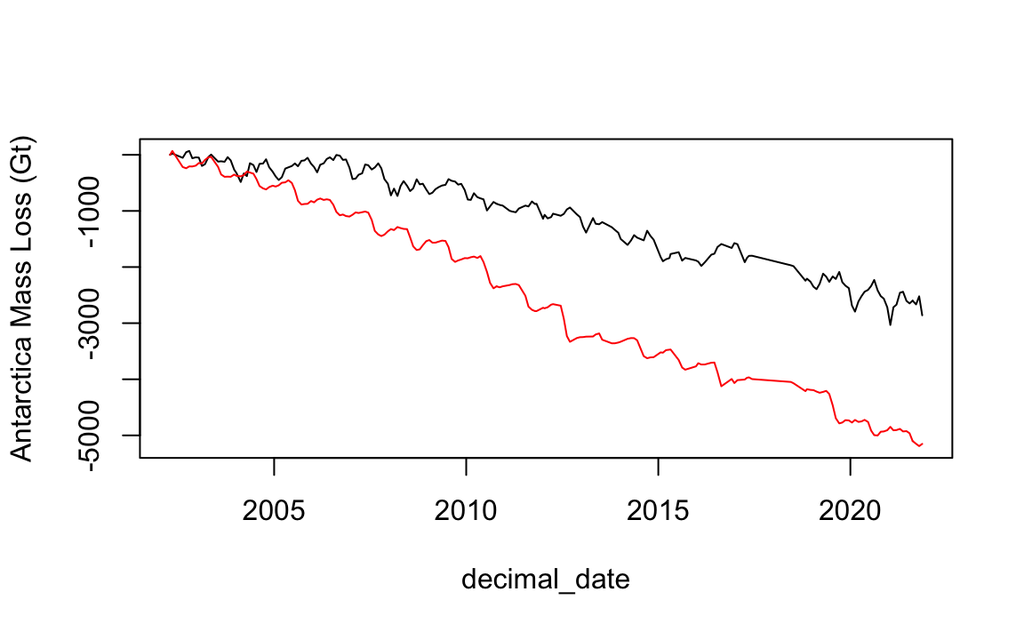

```
## integer(0)
```

```r
plot(mass_Gt ~ decimal_date, data=ant_ice_loss, ylab="Antarctica Mass Loss (Gt)", type='l', ylim=range(grn_ice_loss$mass_Gt)) +
lines(mass_Gt ~ decimal_date, data=grn_ice_loss, type='l', col='red')
```

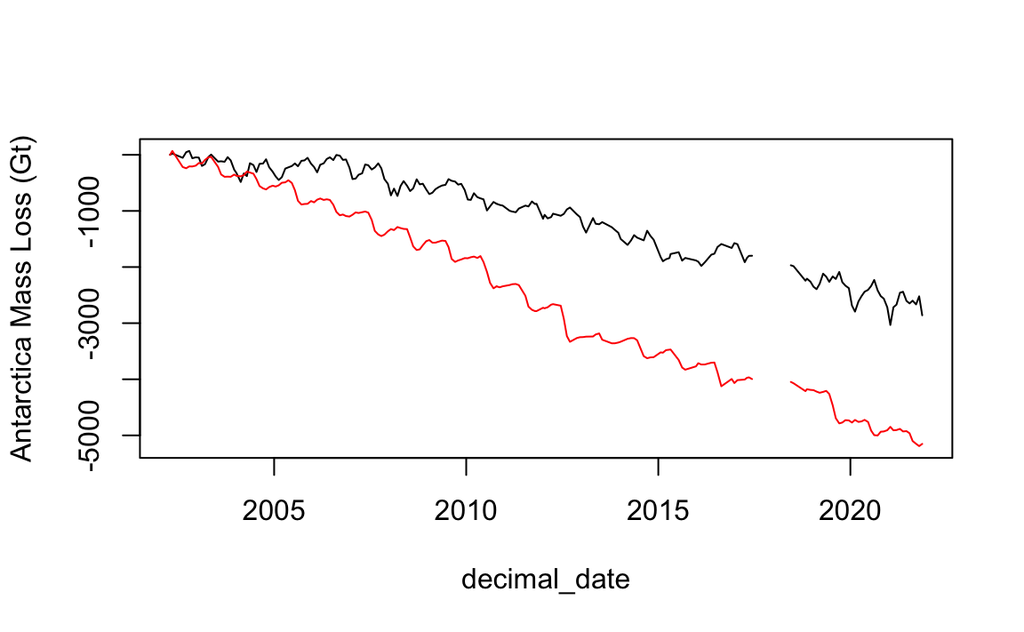

```
## integer(0)
```

```r
#Create data.frame with an NA between the GRACE missions. Column names must match so it will merge with ant and grn data
data_break = data.frame(decimal_date=2018.0, mass_Gt=NA, sigma_Gt=NA)
data_break
##   decimal_date mass_Gt sigma_Gt
## 1         2018      NA       NA

#Add NA data point to the Antarctica ice trends data frame
ant_ice_loss_with_NA = rbind(ant_ice_loss, data_break) # Merge ant_ice_loss data frame with our NA point
tail(ant_ice_loss_with_NA) # Our NA value in 2018 is now the last row of our data frame
##     decimal_date  mass_Gt sigma_Gt
## 199      2021.54 -2648.11    33.23
## 200      2021.62 -2599.30    39.34
## 201      2021.71 -2665.98    46.24
## 202      2021.79 -2521.55    54.16
## 203      2021.87 -2859.92    63.49
## 204      2018.00       NA       NA
order(ant_ice_loss_with_NA$decimal_date) # Use order() to list the indices of the data after its sorted from smallest to biggest
##   [1]   1   2   3   4   5   6   7   8   9  10  11  12  13  14  15  16  17  18
##  [19]  19  20  21  22  23  24  25  26  27  28  29  30  31  32  33  34  35  36
##  [37]  37  38  39  40  41  42  43  44  45  46  47  48  49  50  51  52  53  54
##  [55]  55  56  57  58  59  60  61  62  63  64  65  66  67  68  69  70  71  72
##  [73]  73  74  75  76  77  78  79  80  81  82  83  84  85  86  87  88  89  90
##  [91]  91  92  93  94  95  96  97  98  99 100 101 102 103 104 105 106 107 108
## [109] 109 110 111 112 113 114 115 116 117 118 119 120 121 122 123 124 125 126
## [127] 127 128 129 130 131 132 133 134 135 136 137 138 139 140 141 142 143 144
## [145] 145 146 147 148 149 150 151 152 153 154 155 156 157 158 159 160 161 162
## [163] 163 204 164 165 166 167 168 169 170 171 172 173 174 175 176 177 178 179
## [181] 180 181 182 183 184 185 186 187 188 189 190 191 192 193 194 195 196 197
## [199] 198 199 200 201 202 203
ant_ice_loss_with_NA = ant_ice_loss_with_NA[order(ant_ice_loss_with_NA$decimal_date),] # Reorder the data frame, sorting by date

#Repeat with Greenland data.frame
grn_ice_loss_with_NA = rbind(grn_ice_loss, data_break) # Merge grn_ice_loss data frame with our NA point
grn_ice_loss_with_NA = grn_ice_loss_with_NA[order(grn_ice_loss_with_NA$decimal_date),]

plot(mass_Gt ~ decimal_date, data=ant_ice_loss_with_NA, ylab="Antarctica Mass Loss (Gt)", type='l', ylim=range(grn_ice_loss_with_NA$mass_Gt, na.rm=TRUE)) +
lines(mass_Gt ~ decimal_date, data=grn_ice_loss_with_NA, type='l', col='red')
```

NASA provided sigma, or one standard deviation, uncertainty data, which represents 68% of uncertainty. (Note in the header, they call it “1-sigma”, but this doesn’t mean “one minus the standard deviation”, it means “one standard deviation”). However, in science, sometimes we show errors as “2-sigma”, where 2 X sigma represents 95% uncertainty. We can plot 95% confidence intervals around the data by adding and subtracting 2*sigma from the mass loss estimates

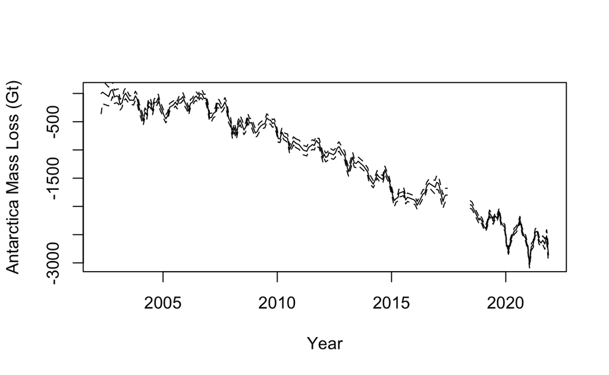

```
## integer(0)
```

```r
head(ant_ice_loss_with_NA)
##   decimal_date mass_Gt sigma_Gt
## 1      2002.29    0.00   178.90
## 2      2002.35   23.21   102.47
## 3      2002.62  -53.37    83.09
## 4      2002.71   46.69    97.19
## 5      2002.79   69.68    61.82
## 6      2002.87  -60.96    58.68
plot(mass_Gt ~ decimal_date, data=ant_ice_loss_with_NA, ylab="Antarctica Mass Loss (Gt)", xlab="Year", type='l') +
lines((mass_Gt+2*sigma_Gt) ~ decimal_date, data=ant_ice_loss_with_NA, type='l', lty='dashed') +
lines((mass_Gt-2*sigma_Gt) ~ decimal_date, data=ant_ice_loss_with_NA, type='l', lty='dashed')
```

### Exercise 1.1:

Create the same time series figure with 95% confidence intervals for the Greenland ice sheet mass loss.

### Saving plots to hard drive

Now we can combine our Antarctic and Greenland time series plots into the same plot and save our nice figure:

```r
pdf('figures/ice_mass_trends.pdf', width=7, height=5)
plot(mass_Gt ~ decimal_date, data=ant_ice_loss_with_NA, ylab="Ice Sheet Mass Loss (Gt)", xlab="Year", type='l', ylim=range(grn_ice_loss_with_NA$mass_Gt, na.rm=TRUE), lwd=2) +
lines((mass_Gt+2*sigma_Gt) ~ decimal_date, data=ant_ice_loss_with_NA, type='l', lty='dashed') +
lines((mass_Gt-2*sigma_Gt) ~ decimal_date, data=ant_ice_loss_with_NA, type='l', lty='dashed') +
lines(mass_Gt ~ decimal_date, data=grn_ice_loss_with_NA, type='l', col='red', lwd=2) +
lines((mass_Gt+2*sigma_Gt) ~ decimal_date, data=grn_ice_loss_with_NA, type='l', lty='dashed', col="red") +
lines((mass_Gt-2*sigma_Gt) ~ decimal_date, data=grn_ice_loss_with_NA, type='l', lty='dashed', col="red")
## integer(0)
dev.off()
## quartz_off_screen
##                 2
```

Let’s make a bar plot showing the difference in ice mass loss for Antarctica and Greenland:

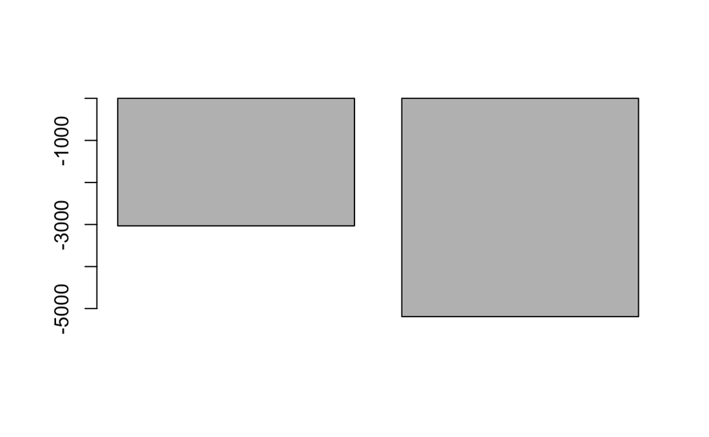

```r
# Largest observed decrease in ice mass loss in Antarctica:
min(ant_ice_loss$mass_Gt)
## [1] -3032.26

# Barplot of largest observed ice loss in Antarctica and Greenland
barplot(height=c(min(ant_ice_loss$mass_Gt), min(grn_ice_loss$mass_Gt)))
```

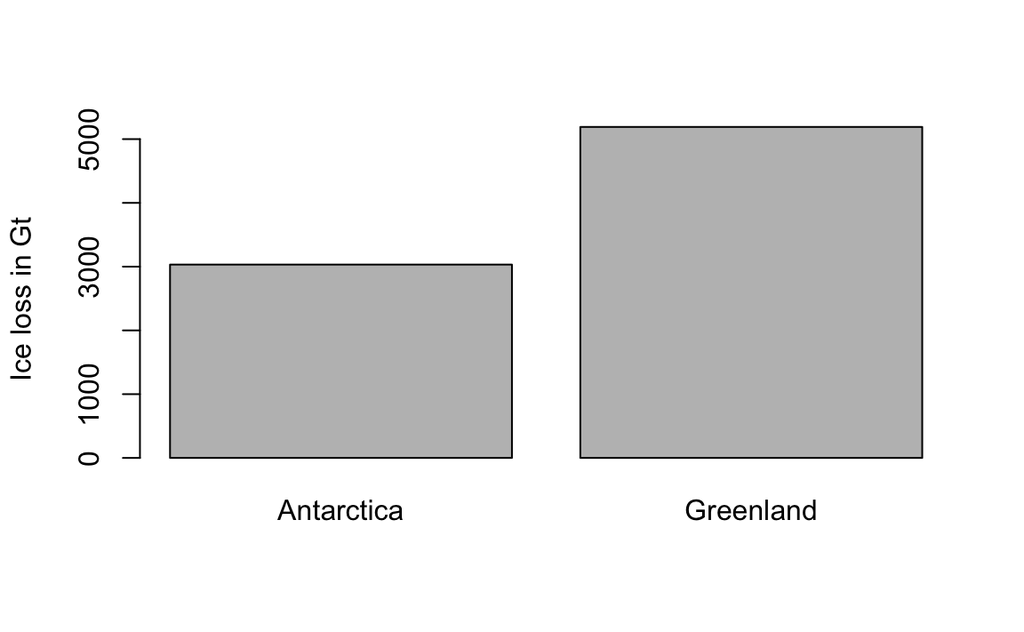

```r
# Flip to negative to positive, add x-axis labels, add more tick marks on y-axis, add y-axis title
barplot(height=c(min(ant_ice_loss$mass_Gt)*(-1), min(grn_ice_loss$mass_Gt)*(-1)), names.arg=c("Antarctica","Greenland"), ylim=c(0,5000), ylab="Ice loss in Gt")
```

### Exercise 1.2:

Calculate the average annual ice loss (a.k.a. the annual rate of ice loss) for each ice sheet by dividing the change in ice lost from the beginning to the end of the time series by the total time that passed. Then display the ice loss rates in a bar graph. Save the bar graph into the `figures/` directory in this repo.